# Midterm Project - Diabetes Indicators

# Introduction

- Diabetes is a complex metabolic syndrome and its involvement in cardiovascular disease is manifold with varying manifestations and different clinical symptoms and prognosis. Although being probably the most important risk factor, diabetes is often considered an “accompanying comorbidity” for cardiac or peripheral artery disease, hypertension, or stroke. An interesting study demonstrated that the risk of sudden cardiac death is at least 2-fold higher in patients who are diabetic compared with those who are nondiabetic, regardless of the extent of cardiac dysfunction or symptoms of heart failure. In contrast, the risk of nonsudden cardiac death was not signiﬁcantly different between the 2 groups.
- Preventing sudden cardiac death by analyzing diabetes is worth trying as it is the leading cause of death in the United States. The object of this study is to find out if diabetes risk prediction is possible based on family history and genetic factors along with other risk factors. This study is focused on whether Diabetes Pedigree Function is truly associated with outcome and if so, what risk factors are significantly related with it. The association between Diabetes Pedigree Function and disease status would reveal to what extent does the genetic factors affects diabetes. The dataset did not separate type 1 diabetes and type 2 dabetes. Regardless of the type of diabetes, however, Diabetes Pedigree Function can be assessed as family history is one of the important risk factors for both type of diabetes. In the analysis, important indicators of diabetes will be evaluated together.

# Methods

- Linear regression was performed for the association between Diabetes Pedigree Function and outcome, including the examination of the effect of lipotoxicity, glucose level, Blood Pressure, Skin Thickness, insulin level, BMI, and age. The dataset was downloaded from Haverd Dataverse and the reference is stated below. The data was cleaned by replacing extreme values to ’NA’s, shortening variable names, and creating new factor variable for better analysis. Skim function from skimr package was used to explore data. Dim, head and tail, summary, and table functions were used to check detailed observations.
- Reference: P. Rodgers, Judith, 2020, “Diabetes Mellitus “Comorbidity” or an Important Risk Factor?", https://doi.org/10.7910/DVN/JAW6AX, Harvard Dataverse, V2, UNF:6:QOwrJ53n2F5fMC+wb4ADVA== [fileUNF]
- Key question: Whether diabetes risk factors are associated with the outcome. Whether Diabetes Pedigree Function has significant association with outcome and other risk factors.

```r
library(tidyverse)
library(skimr)
library(olsrr)
```

# Data description

- Lipotoxicity: lipotoxicity is a metabolic syndrome that results from the accumulation of lipid intermediates in non-adipose tissue, leading to cellular dysfunction and death.
- Glucose: blood glucose level is the concentration of glucose present in the blood.
- BloodPressure: the pressure of the blood in the circulatory system.
- SkinThickness: skin thickness is primarily determined by collagen content and is increased in insulin-dependent diabetes mellitus (IDDM).
- Insulin: insulin is an anabolic hormone that promotes glucose uptake.
- BMI: body mass index (BMI) is a person’s weight in kilograms divided by the square of height in meters.
- DiabetesPedigreeFunction: diabetes pedigree function provides “a synthesis of the diabetes mellitus history in relatives and the genetic relationship of those relatives to the subject.” It utilizes information from a person’s family history to predict how diabetes will affect that individual.
- Age: age of the individual.
- Outcome: diabetes diagosis.

```r
diabetes <- read_csv("data/diabetes.csv")
```

# Exploratory Data Analysis

- The total dataset includes 768 observations with 9 vaiables.
- Lipotoxicity is right skewed and ranged from 0 to 17 with mean of 3.85.
- Glucose level is not skewed to either side and ranged from 0 to 199 with mean of 121.
- Blood Pressure is also not skewed and ranged from 0 to 122 with mean of 69.1.
- Skin Thickness right skewed and ranged from 0 to 99.
- Insulin level is extremly right skewed and ranged from 0 to 846.
- BMI is fairly normally distributed and ranged from 0 to 67.1.
- Diabetes Pedigree Function is right skewed and ranged from 0.078 to 2.42.
- Age is right skewed and ranged from 21 to 81. Right skewed age data displays more than 50% of observations are in the age group of 20 to 29. This data is more focused on young population.
- Outcome has binary results with mean of 0.349 which means 34.9% of all observations have diabetes positive outcome.

```r
skim(diabetes)
```

Data summary

| Name | diabetes |
| --- | --- |
| Number of rows | 768 |
| Number of columns | 9 |
| _______________________ |  |
| Column type frequency: |  |
| numeric | 9 |
| ________________________ |  |
| Group variables | None |

**Variable type: numeric**

| skim_variable | n_missing | complete_rate | mean | sd | p0 | p25 | p50 | p75 | p100 | hist |
| --- | --- | --- | --- | --- | --- | --- | --- | --- | --- | --- |
| Lipotoxicity | 0 | 1 | 3.85 | 3.37 | 0.00 | 1.00 | 3.00 | 6.00 | 17.00 | ▇▃▂▁▁ |
| Glucose | 0 | 1 | 120.89 | 31.97 | 0.00 | 99.00 | 117.00 | 140.25 | 199.00 | ▁▁▇▆▂ |
| BloodPressure | 0 | 1 | 69.11 | 19.36 | 0.00 | 62.00 | 72.00 | 80.00 | 122.00 | ▁▁▇▇▁ |
| SkinThickness | 0 | 1 | 20.54 | 15.95 | 0.00 | 0.00 | 23.00 | 32.00 | 99.00 | ▇▇▂▁▁ |
| Insulin | 0 | 1 | 79.80 | 115.24 | 0.00 | 0.00 | 30.50 | 127.25 | 846.00 | ▇▁▁▁▁ |
| BMI | 0 | 1 | 31.99 | 7.88 | 0.00 | 27.30 | 32.00 | 36.60 | 67.10 | ▁▃▇▂▁ |
| DiabetesPedigreeFunction | 0 | 1 | 0.47 | 0.33 | 0.08 | 0.24 | 0.37 | 0.63 | 2.42 | ▇▃▁▁▁ |
| Age | 0 | 1 | 33.24 | 11.76 | 21.00 | 24.00 | 29.00 | 41.00 | 81.00 | ▇▃▁▁▁ |
| Outcome | 0 | 1 | 0.35 | 0.48 | 0.00 | 0.00 | 0.00 | 1.00 | 1.00 | ▇▁▁▁▅ |

- 0 values in all risk factors are speculated as an absence of the specific test outcome because there were significant different in values between all 0s and the next minimum values of each variable. All of them are edited to “NA”s.

```r
db <-
  diabetes %>%
  mutate(Lipotoxicity = replace(Lipotoxicity, Lipotoxicity==0, NA))%>%
  mutate(Glucose = replace(Glucose, Glucose==0, NA)) %>%
  mutate(BloodPressure = replace(BloodPressure, BloodPressure==0, NA)) %>%
  mutate(SkinThickness = replace(SkinThickness, SkinThickness==0, NA)) %>%
  mutate(Insulin = replace(Insulin, Insulin==0, NA)) %>%
  mutate(BMI = replace(BMI, BMI==0, NA))
```

- Variable names are renamed into lowercase letters with shorter length.

```r
db <-
  db %>%
  rename(
    lip = Lipotoxicity,
    glu = Glucose,
    bp = BloodPressure,
    st = SkinThickness,
    ins = Insulin,
    bmi = BMI,
    dpf = DiabetesPedigreeFunction,
    age = Age,
    outcome = Outcome
    )
```

- Create age groups to compare proportion of the diabetes by age groups.

```r
db$age_group <- ifelse(db$age < 30, "20-29",
                         ifelse(db$age >= 30 & db$age < 40, "30-39",
                                ifelse(db$age >= 40 & db$age < 50, "40-49", "50+")))
```

```r
table(diabetes$Lipotoxicity)
table(db$Lipotoxicity)

table(diabetes$BloodPressure)
table(db$BloodPressure)

table(diabetes$SkinThickness)
table(db$SkinThickness)

table(diabetes$Insulin)
table(db$Insulin)

table(diabetes$BMI)
table(db$BMI)

table(diabetes$DiabetesPedigreeFunction)
table(db$BMI)
```

# Preliminary results (regression model & data visualization)

### Disease outcome by age_groups.

- Age is significant risk factor of diabetes

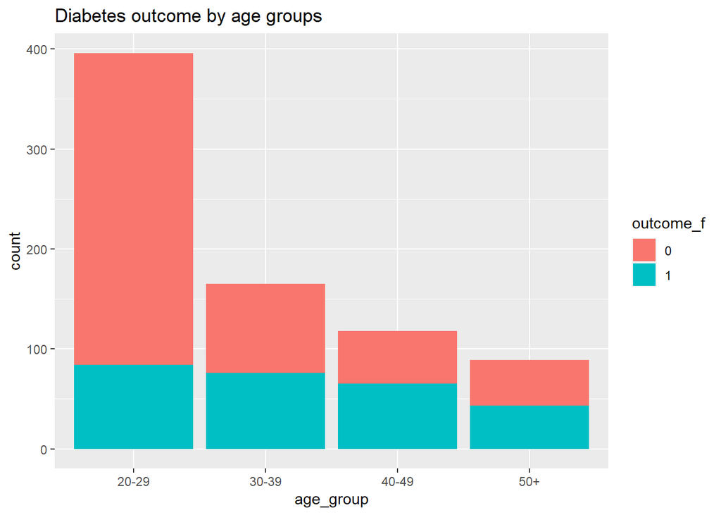

```r
db <-
  db %>%
  mutate(outcome_f = factor(outcome))

db %>%
  ggplot()+
  geom_bar(mapping = aes(x = age_group, fill = outcome_f, stat="identity"))+
  labs(title = "Diabetes outcome by age groups")
```

```r
model_agegroup <- lm(outcome ~ age_group, data=db)
summary(model_agegroup)
```

```
##
## Call:
## lm(formula = outcome ~ age_group, data = db)
##
## Residuals:
##     Min      1Q  Median      3Q     Max
## -0.5508 -0.2121 -0.2121  0.5169  0.7879
##
## Coefficients:
##                Estimate Std. Error t value Pr(>|t|)
## (Intercept)     0.21212    0.02290   9.265  < 2e-16 ***
## age_group30-39  0.24848    0.04222   5.886 5.93e-09 ***
## age_group40-49  0.33873    0.04778   7.089 3.09e-12 ***
## age_group50+    0.27102    0.05345   5.071 4.97e-07 ***
## ---
## Signif. codes:  0 '***' 0.001 '**' 0.01 '*' 0.05 '.' 0.1 ' ' 1
##
## Residual standard error: 0.4556 on 764 degrees of freedom
## Multiple R-squared:  0.09104,    Adjusted R-squared:  0.08747
## F-statistic: 25.51 on 3 and 764 DF,  p-value: 9.863e-16
```

### Preliminary regression model

- linear regression and multiple regression was performed.
- No significant colliniarity was detected by examining variace inflation factor.
- Model 2 should be used for analysis as it has greater R-squared value while remaining statistical significance (p < 0.05).

```r
model1 <- lm(outcome ~ dpf, data=db)

summary(model1)
```

```
##
## Call:
## lm(formula = outcome ~ dpf, data = db)
##
## Residuals:
##     Min      1Q  Median      3Q     Max
## -0.8137 -0.3375 -0.2849  0.5963  0.7471
##
## Coefficients:
##             Estimate Std. Error t value Pr(>|t|)
## (Intercept)  0.23087    0.02953   7.819 1.76e-14 ***
## dpf          0.25025    0.05122   4.886 1.25e-06 ***
## ---
## Signif. codes:  0 '***' 0.001 '**' 0.01 '*' 0.05 '.' 0.1 ' ' 1
##
## Residual standard error: 0.47 on 766 degrees of freedom
## Multiple R-squared:  0.03022,    Adjusted R-squared:  0.02896
## F-statistic: 23.87 on 1 and 766 DF,  p-value: 1.255e-06
```

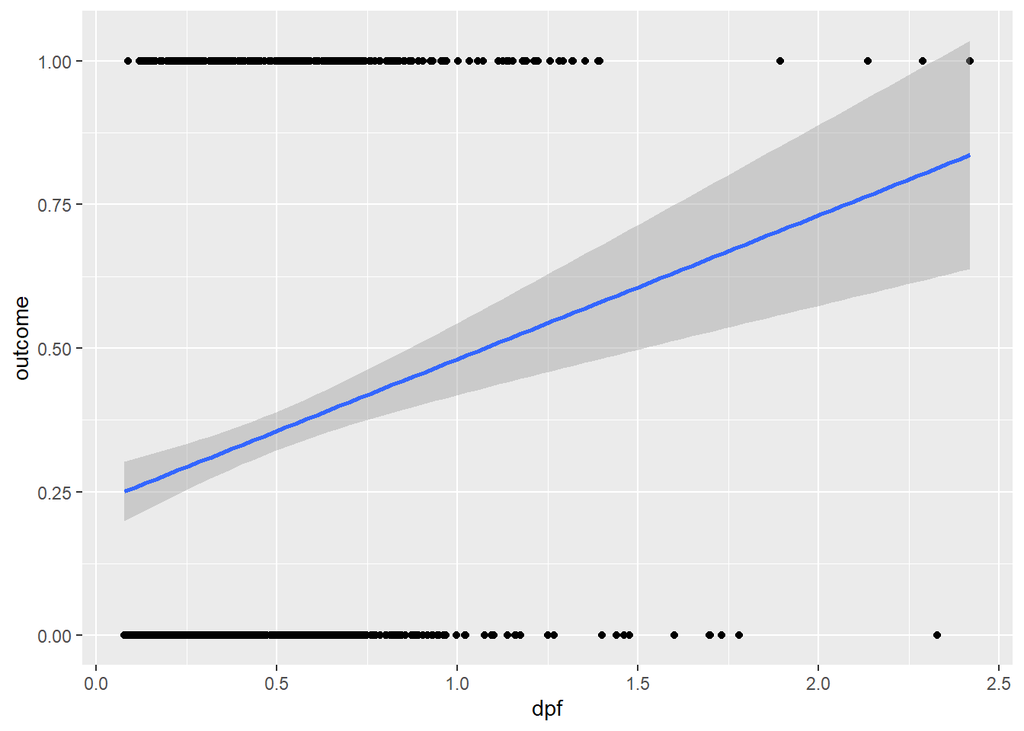

```r
model1 %>%
  ggplot(mapping = aes(y=outcome, x=dpf))+
  geom_point()+
  geom_smooth(method=lm)
```

```r
model2 <- lm(outcome ~ dpf + lip + glu + bp + st + ins + bmi + age, data=db)

summary(model2)
```

```
##
## Call:
## lm(formula = outcome ~ dpf + lip + glu + bp + st + ins + bmi +
##     age, data = db)
##
## Residuals:
##      Min       1Q   Median       3Q      Max
## -1.10824 -0.26481 -0.03969  0.27008  1.05149
##
## Coefficients:
##               Estimate Std. Error t value Pr(>|t|)
## (Intercept) -1.169e+00  1.620e-01  -7.214 3.81e-12 ***
## dpf          1.544e-01  6.529e-02   2.365   0.0186 *
## lip          1.126e-02  9.101e-03   1.238   0.2167
## glu          5.904e-03  8.887e-04   6.644 1.28e-10 ***
## bp           1.183e-03  1.879e-03   0.630   0.5293
## st           2.039e-03  2.698e-03   0.756   0.4504
## ins          7.306e-07  2.243e-04   0.003   0.9974
## bmi          9.089e-03  4.414e-03   2.059   0.0403 *
## age          6.858e-03  2.896e-03   2.368   0.0185 *
## ---
## Signif. codes:  0 '***' 0.001 '**' 0.01 '*' 0.05 '.' 0.1 ' ' 1
##
## Residual standard error: 0.3827 on 327 degrees of freedom
##   (432 observations deleted due to missingness)
## Multiple R-squared:  0.3557, Adjusted R-squared:  0.3399
## F-statistic: 22.57 on 8 and 327 DF,  p-value: < 2.2e-16
```

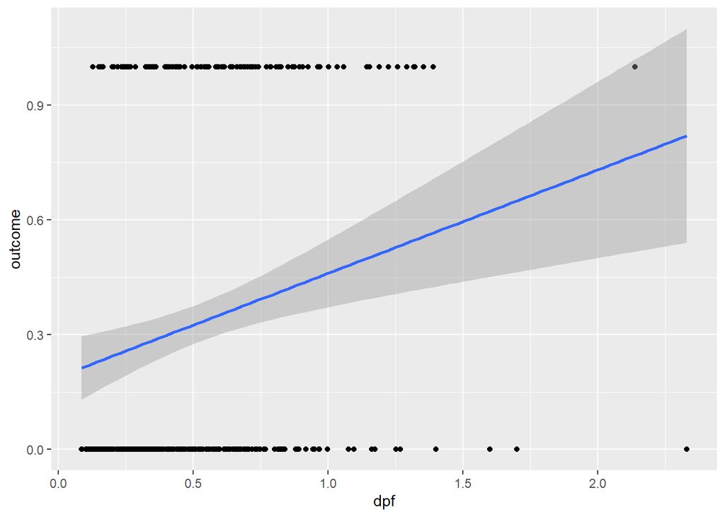

```r
model2 %>%
  ggplot(mapping = aes(y=outcome, x=dpf))+
  geom_point()+
  geom_smooth(method=lm)
```

```r
model2 %>% ols_vif_tol()
```

```
##   Variables Tolerance      VIF
## 1       dpf 0.9550433 1.047073
## 2       lip 0.5324636 1.878063
## 3       glu 0.5840286 1.712245
## 4        bp 0.8105058 1.233798
## 5        st 0.5716614 1.749287
## 6       ins 0.6161025 1.623107
## 7       bmi 0.5532702 1.807435
## 8       age 0.4765168 2.098562
```

- Check difference between each risk factors by disease status (1: diagnosed diabetes, 0: No diabetes): all indicators in diabetes group has higher values.

```r
db_ot <-
  db %>%
  group_by(outcome)

db_table <-
  db_ot %>%
  summarise(
    DiabetesPedigreeFunction=mean(dpf),
    Lipotoxicity=mean(lip, na.rm = TRUE),
    Glucose=mean(glu, na.rm = TRUE),
    BloodPressur=mean(bp, na.rm = TRUE),
    SkinThickness=mean(st, na.rm = TRUE),
    Insulin=mean(ins, na.rm = TRUE),
    BMI=mean(bmi, na.rm = TRUE),
    Age=mean(age, na.rm = TRUE),
    )
knitr::kable(db_table, align= "c", digits = 4, caption = "Mean of each risk factors by outcome group")
```

Mean of each risk factors by outcome group

| outcome | DiabetesPedigreeFunction | Lipotoxicity | Glucose | BloodPressur | SkinThickness | Insulin | BMI | Age |
| --- | --- | --- | --- | --- | --- | --- | --- | --- |
| 0 | 0.4297 | 3.8618 | 110.6439 | 70.8773 | 27.2355 | 130.2879 | 30.8597 | 31.1900 |
| 1 | 0.5505 | 5.6696 | 142.3195 | 75.3214 | 33.0000 | 206.8462 | 35.4068 | 37.0672 |

#### regression model for the association between dpf and other risk factors.

- Lipotoxicity vs Diabetes Pedigree Function: no association (p > 0.05).

```r
model_lip <- lm(lip ~ dpf, data=db)
summary(model_lip)
```

```
##
## Call:
## lm(formula = lip ~ dpf, data = db)
##
## Residuals:
##     Min      1Q  Median      3Q     Max
## -3.5195 -2.5084 -0.5098  2.4856 12.5287
##
## Coefficients:
##             Estimate Std. Error t value Pr(>|t|)
## (Intercept)  4.52537    0.22418  20.186   <2e-16 ***
## dpf         -0.06621    0.40053  -0.165    0.869
## ---
## Signif. codes:  0 '***' 0.001 '**' 0.01 '*' 0.05 '.' 0.1 ' ' 1
##
## Residual standard error: 3.22 on 655 degrees of freedom
##   (111 observations deleted due to missingness)
## Multiple R-squared:  4.172e-05,  Adjusted R-squared:  -0.001485
## F-statistic: 0.02733 on 1 and 655 DF,  p-value: 0.8688
```

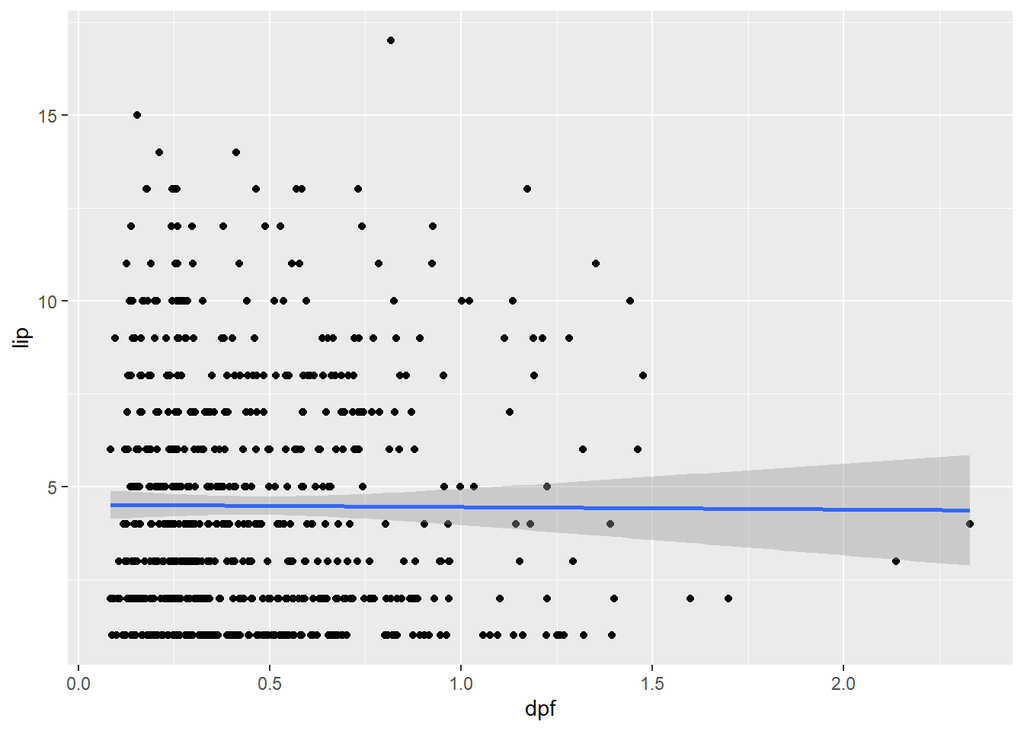

```r
model_lip %>%
  ggplot(mapping = aes(y=lip, x=dpf))+
  geom_point()+
  geom_smooth(method=lm)
```

- Glucose level vs Diabetes Pedigree Function: The association is statistically significant (p < 0.001).

```r
model_glu <- lm(glu ~ dpf, data=db)
summary(model_glu)
```

```
##
## Call:
## lm(formula = glu ~ dpf, data = db)
##
## Residuals:
##     Min      1Q  Median      3Q     Max
## -79.133 -22.119  -4.673  18.984  79.283
##
## Coefficients:
##             Estimate Std. Error t value Pr(>|t|)
## (Intercept)  115.722      1.907  60.689  < 2e-16 ***
## dpf           12.625      3.303   3.822 0.000143 ***
## ---
## Signif. codes:  0 '***' 0.001 '**' 0.01 '*' 0.05 '.' 0.1 ' ' 1
##
## Residual standard error: 30.27 on 761 degrees of freedom
##   (5 observations deleted due to missingness)
## Multiple R-squared:  0.01884,    Adjusted R-squared:  0.01755
## F-statistic: 14.61 on 1 and 761 DF,  p-value: 0.000143
```

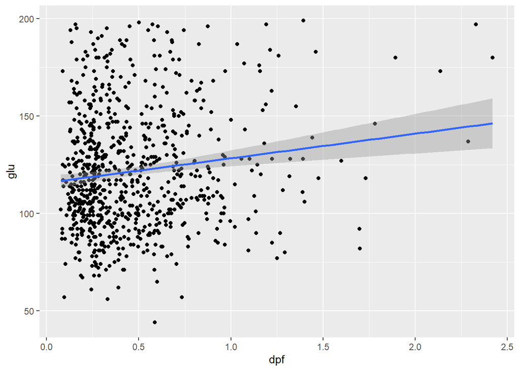

```r
model_glu %>%
  ggplot(mapping = aes(y=glu, x=dpf))+
  geom_point()+
  geom_smooth(method=lm)
```

- Blood Pressure vs Diabetes Pedigree Function: No association (p > 0.05).

```r
model_bp <- lm(bp ~ dpf, data=db)
summary(model_bp)
```

```
##
## Call:
## lm(formula = bp ~ dpf, data = db)
##
## Residuals:
##     Min      1Q  Median      3Q     Max
## -48.397  -8.407  -0.400   7.587  49.567
##
## Coefficients:
##             Estimate Std. Error t value Pr(>|t|)
## (Intercept)  72.4546     0.7967  90.944   <2e-16 ***
## dpf          -0.1039     1.3704  -0.076     0.94
## ---
## Signif. codes:  0 '***' 0.001 '**' 0.01 '*' 0.05 '.' 0.1 ' ' 1
##
## Residual standard error: 12.39 on 731 degrees of freedom
##   (35 observations deleted due to missingness)
## Multiple R-squared:  7.865e-06,  Adjusted R-squared:  -0.00136
## F-statistic: 0.00575 on 1 and 731 DF,  p-value: 0.9396
```

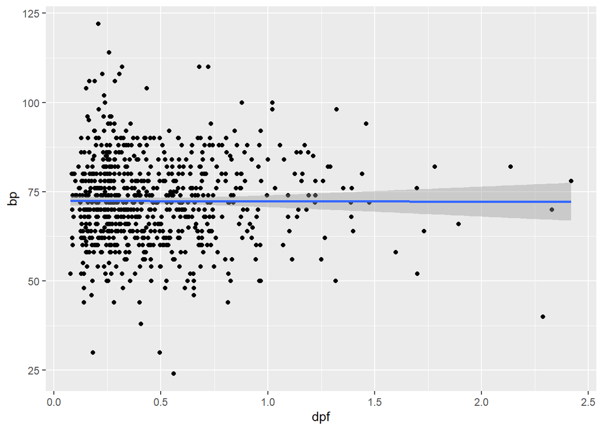

```r
model_bp %>%
  ggplot(mapping = aes(y=bp, x=dpf))+
  geom_point()+
  geom_smooth(method=lm)
```

- Skin Thickness vs Diabetes Pedigree Function: The association is statistically significant (p < 0.01).

```r
model_st <- lm(st ~ dpf, data=db)
summary(model_st)
```

```
##
## Call:
## lm(formula = st ~ dpf, data = db)
##
## Residuals:
##     Min      1Q  Median      3Q     Max
## -23.617  -7.809  -0.206   7.020  69.603
##
## Coefficients:
##             Estimate Std. Error t value Pr(>|t|)
## (Intercept)  27.3984     0.7917  34.606  < 2e-16 ***
## dpf           3.4763     1.2932   2.688  0.00741 **
## ---
## Signif. codes:  0 '***' 0.001 '**' 0.01 '*' 0.05 '.' 0.1 ' ' 1
##
## Residual standard error: 10.42 on 539 degrees of freedom
##   (227 observations deleted due to missingness)
## Multiple R-squared:  0.01323,    Adjusted R-squared:  0.0114
## F-statistic: 7.226 on 1 and 539 DF,  p-value: 0.007408
```

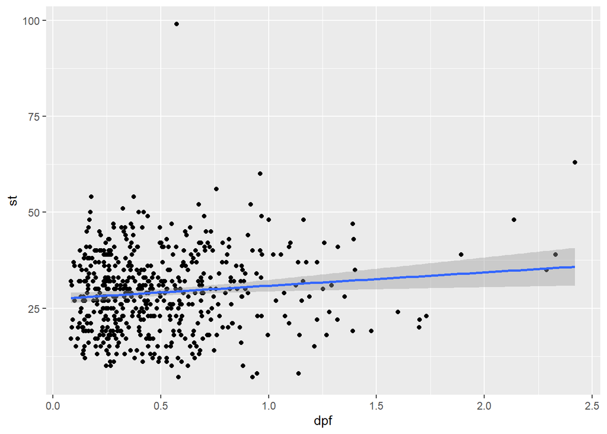

```r
model_st %>%
  ggplot(mapping = aes(y=st, x=dpf))+
  geom_point()+
  geom_smooth(method=lm)
```

- Insulin level vs Diabetes Pedigree Function: The association is statistically significant (p < 0.01).

```r
model_ins <- lm(ins ~ dpf, data=db)
summary(model_ins)
```

```
##
## Call:
## lm(formula = ins ~ dpf, data = db)
##
## Residuals:
##     Min      1Q  Median      3Q     Max
## -225.35  -76.23  -29.48   33.46  696.09
##
## Coefficients:
##             Estimate Std. Error t value Pr(>|t|)
## (Intercept)   132.30      10.72  12.338  < 2e-16 ***
## dpf            44.23      16.99   2.604  0.00957 **
## ---
## Signif. codes:  0 '***' 0.001 '**' 0.01 '*' 0.05 '.' 0.1 ' ' 1
##
## Residual standard error: 117.9 on 392 degrees of freedom
##   (374 observations deleted due to missingness)
## Multiple R-squared:  0.017,  Adjusted R-squared:  0.0145
## F-statistic:  6.78 on 1 and 392 DF,  p-value: 0.009567
```

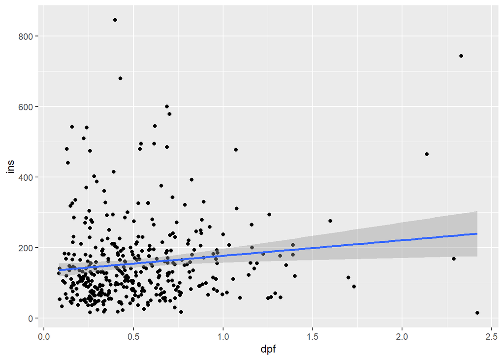

```r
model_ins %>%
  ggplot(mapping = aes(y=ins, x=dpf))+
  geom_point()+
  geom_smooth(method=lm)
```

- BMI vs Diabetes Pedigree Function: The association is statistically significant (p < 0.001).

```r
model_bmi <- lm(bmi ~ dpf, data=db)
summary(model_bmi)
```

```
##
## Call:
## lm(formula = bmi ~ dpf, data = db)
##
## Residuals:
##     Min      1Q  Median      3Q     Max
## -14.752  -4.987  -0.484   4.156  35.144
##
## Coefficients:
##             Estimate Std. Error t value Pr(>|t|)
## (Intercept)  30.9145     0.4351  71.045  < 2e-16 ***
## dpf           3.2659     0.7556   4.322 1.75e-05 ***
## ---
## Signif. codes:  0 '***' 0.001 '**' 0.01 '*' 0.05 '.' 0.1 ' ' 1
##
## Residual standard error: 6.845 on 755 degrees of freedom
##   (11 observations deleted due to missingness)
## Multiple R-squared:  0.02414,    Adjusted R-squared:  0.02285
## F-statistic: 18.68 on 1 and 755 DF,  p-value: 1.754e-05
```